# Dia 3: Protistas

En este módulo combinamos el uso del sistema operativo linux con anaconda y jupyter lab. Si se cuenta con una computadora con sistema operativo Windows11 es posible montar una sistema linux de forma nativa siguiendo los pasos que se muestran a continuación:

- Instalar el WSL de windows por medio de la Microsoft Store
- Instalar el sistema operativo Ubuntu (recomendado)

Una vez que podamos ingresar a la terminal de Ubuntu, procedemos a instalar anaconda

# Descargar el instalador wget https://repo.anaconda.com/miniconda/Miniconda3-latest-Linux-x86_64.sh # Ejecutar el instalador contestando que si (yes) a todo bash Miniconda3-latest-Linux-x86_64.sh # Reiniciar la terminal source .bashrc

Procedemos a instalar el ambiente de anaconda desde donde vamos a lanzar el sistema jupyter lab, que es la interfaz gráfica que nos permite trabajar con bitacoras de codigo. Luego activamos el ambiente e iniciamos el servicio de jupyter lab.

# Instalar el ambiente contestando que si (yes) a todo conda create -n jupyter jupyterlab # Activar el ambiente conda activate jupyter # Iniciar el servicio de jupyter jupyter lab --no-browser

La terminal va a mostrar varios mensajes. Para acceder a jupyterlab vamos a copiar la primera direccion URL que se muestra en la terminal y pegarla en la barra de busqueda de un navegador web (se recomienda usar google chrome).

Dentro del jupyter lab vamos a abrir una terminal con el boton negro que dice "terminal" del menu principal. En la terminal vamos a crear el directorio de trabajo del dia 3:

# Crear directorio mkdir dia3 # Moverse al directorio cd dia3

También desde el navegador de archivos del lado izquierdo de jupyter lab entramos al directorio `dia3` dándole doble click.

A continuación descargamos los datos suplementarios del artículo [Effects of Land-Use and Vertical Compartmentalization on Eukaryotic Soil Algal Community Turnover in Peri-Urban Mexico City](https://www.mdpi.com/2673-9410/6/2/55). Posteriormente subimos el archivo ZIP al jupyter lab usando el boton de subir archivos que se encuentra en el navegador de archivos y tiene forma de flecha apuntando hacia arriba.

Desde la terminal descomprimimos el archivo de datos suplementarios:

# Instalar unzip sudo apt-get install unzip # Descomprimir unzip phycology-06-00055-s001.zip

Para comenzar a trabajar en una bitácora de jupyter notebook, abrimos una nueva pestaña en la pantalla principal de jupyter lab dando click al botón con el simbolo de `+`. Ahora damos click al boton con el logo de python que dice "Pyton 3 (ipykernel)" justo debajo del encabezado que dice "Notebook".

Vamos a recordar algunas teclas rápidas que se usan para trabajar en un jupyter notebook:

- `a` crear una celda arriba de la actual (above)
- `b` crear una celda debajo de la actual (below)
- `ctrl+enter` ejecutar la celda actual
- `m` cambiar la celda a markdown
- `y` cambiar la celda a codigo
- `dd` eliminar la celda actual
- `c` copiar la celda actual
- `v` pegar la celda copiada debajo de la celda actual

# Analisis de datos con python

Comenzamos instalando algunas librerías

```python
pip install plotly
```

[output not shown]

```python
pip install scikit-bio
```

[output not shown]

```python
pip install networkx
```

```
Downloading networkx-3.4.2-py3-none-any.whl (1.7 MB)
   ━━━━━━━━━━━━━━━━━━━━━━━━━━━━━━━━━━━━━━━━ 1.7/1.7 MB 34.8 MB/s eta 0:00:00
```

# Cargar librerías

```python
import pandas as pd
import matplotlib.pyplot as plt
import plotly.express as px
import skbio
import seaborn as sns
import scipy
from statsmodels.stats.multitest import multipletests
import networkx as nx
import numpy as np
```

# Cargar datos

```python
# cargar tabla de datos de OTUs
fulltab = pd.read_csv('phycology-4250186-supplementary-final/File_S1.tsv',
                      sep='\t')
fulltab.info()
```

```
<class 'pandas.core.frame.DataFrame'>
RangeIndex: 23034 entries, 0 to 23033
Data columns (total 45 columns):
 #   Column               Non-Null Count  Dtype
---  ------               --------------  -----
 0   SPPN                 23034 non-null  object
 1   domain               22140 non-null  object
 2   phylum               21700 non-null  object
 3   class                21269 non-null  object
 4   order                19987 non-null  object
 5   family               15703 non-null  object
 6   genus                11738 non-null  object
 7   species              901 non-null    object
 8   primary_lifestyle    9953 non-null   object
 9   Secondary_lifestyle  4961 non-null   object
```

[output cut: 37 more lines]

```python
# cargar tabla de metadatos
samplemd = pd.read_excel('phycology-4250186-supplementary-final/landusealgae_mromero2026_supplementary_tables.xlsx',
                         sheet_name='Table S2', skiprows=1)
samplemd.info()
```

```
<class 'pandas.core.frame.DataFrame'>
RangeIndex: 34 entries, 0 to 33
Data columns (total 22 columns):
 #   Column                     Non-Null Count  Dtype
---  ------                     --------------  -----
 0   Sample                     34 non-null     object
 1   Soil System                34 non-null     object
 2   Vegetation_general         34 non-null     object
 3   Vegetation_description     34 non-null     object
 4   Altitude                   34 non-null     int64
 5   Climate                    34 non-null     object
 6   Soil_type                  34 non-null     object
 7   Municipality               34 non-null     object
 8   Collection_date            34 non-null     object
 9   Latitude                   34 non-null     float64
 10  Longitude                  34 non-null     float64
 11  pH                         34 non-null     float64
 12  Moisture                   34 non-null     float64
 13  Mean_annual_temperature    34 non-null     int64
 14  Mean_annual_precipitation  34 non-null     int64
 15  Mean_evapotranspiration    34 non-null     int64
 16  TC_total_carbon            34 non-null     float64
 17  TN_total_nitrogen          34 non-null     float64
 18  Tpt_total_phosphorus       34 non-null     float64
 19  C/N_ratio                  34 non-null     float64
 20  C/P_ratio                  34 non-null     float64
 21  N/P_ratio                  34 non-null     float64
dtypes: float64(10), int64(4), object(8)
memory usage: 6.0+ KB
```

# Visualizar todo

```python
# metricas de metadatos
samplemd['Altitude']
```

```
0     2980
1     2980
2     3220
3     3676
4     3438
5     2740
6     3220
7     2960
8     2640
9     2600
10    3034
11    3415
12    2680
13    2260
14    2840
```

[output cut: 20 more lines]

```python
# metricas de metadatos
samplemd['Altitude'].min()
```

```
np.int64(2200)
```

```python
# metricas de metadatos
samplemd['Altitude'].max()
```

```
np.int64(3676)
```

```python
# metricas de metadatos
samplemd['Altitude'].mean()
```

```
np.float64(2924.8823529411766)
```

```python
# metricas de metadatos
samplemd['Altitude'].median()
```

```
np.float64(2960.0)
```

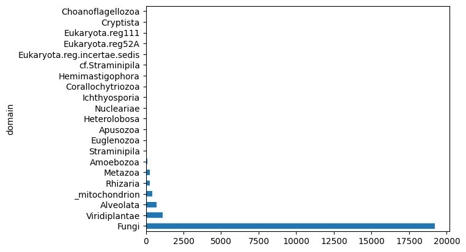

```python
# revisar composicion a nivel de reino
fulltab['domain'].value_counts().plot.barh()
```

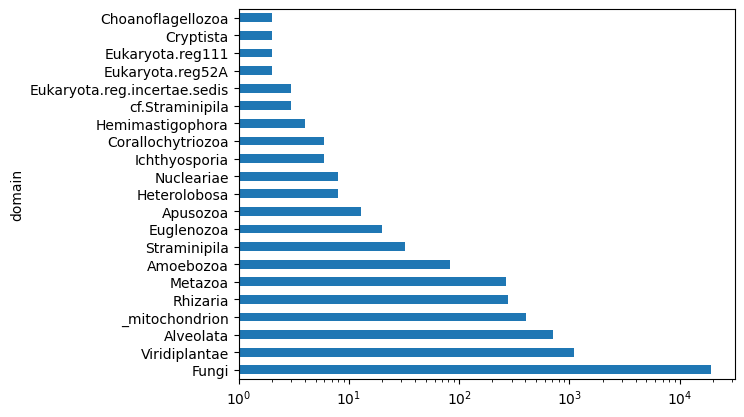

```python
# agregar escala log
fulltab['domain'].value_counts().plot.barh(log=True)
```

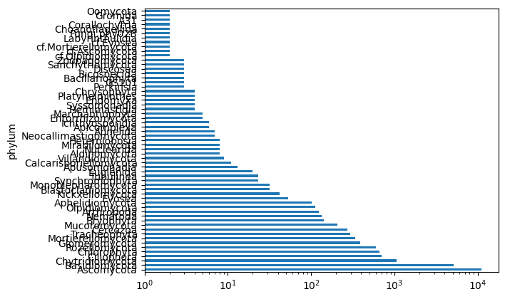

```python
# nivel de phylum
fulltab['phylum'].value_counts().plot.barh(log=True)
```

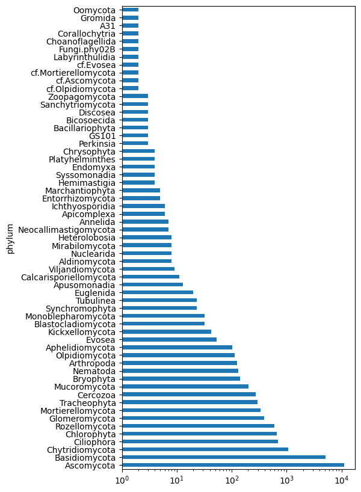

```python
# modificar dimensiones
fig, ax = plt.subplots(figsize=(5,10))
fulltab['phylum'].value_counts().plot.barh(log=True, ax=ax)
```

```python
# crear tabla para visualizar clasificación a diferentes escalas
pd.DataFrame(fulltab.groupby('domain',
                             as_index=False)['phylum'].value_counts())
```

|  | domain | phylum | count |
| --- | --- | --- | --- |
| 0 | Alveolata | Ciliophora | 698 |
| 1 | Alveolata | Apicomplexa | 5 |
| 2 | Alveolata | Perkinsia | 2 |
| 3 | Amoebozoa | Evosea | 52 |
| 4 | Amoebozoa | Tubulinea | 22 |
| 5 | Amoebozoa | Discosea | 2 |
| 6 | Amoebozoa | cf.Evosea | 1 |
| 7 | Apusozoa | Apusomonadia | 12 |
| 8 | Choanoflagellozoa | Choanoflagellida | 1 |
| 9 | Corallochytriozoa | Syssomonadia | 3 |
| 10 | Corallochytriozoa | Corallochytria | 1 |
| 11 | Euglenozoa | Euglenida | 19 |
| 12 | Fungi | Ascomycota | 11076 |
| 13 | Fungi | Basidiomycota | 5150 |
| 14 | Fungi | Chytridiomycota | 1064 |
| 15 | Fungi | Rozellomycota | 599 |
| 16 | Fungi | Glomeromycota | 390 |
| 17 | Fungi | Mortierellomycota | 336 |
| 18 | Fungi | Mucoromycota | 204 |
| 19 | Fungi | Olpidiomycota | 112 |
| 20 | Fungi | Aphelidiomycota | 101 |
| 21 | Fungi | Kickxellomycota | 41 |
| 22 | Fungi | Blastocladiomycota | 31 |
| 23 | Fungi | Monoblepharomycota | 31 |
| 24 | Fungi | Calcarisporiellomycota | 10 |
| 25 | Fungi | Viljandiomycota | 8 |
| 26 | Fungi | Aldinomycota | 7 |
| 27 | Fungi | Mirabilomycota | 7 |
| 28 | Fungi | Neocallimastigomycota | 6 |
| 29 | Fungi | Entorrhizomycota | 4 |
| 30 | Fungi | GS101 | 2 |
| 31 | Fungi | Sanchytriomycota | 2 |
| 32 | Fungi | Zoopagomycota | 2 |
| 33 | Fungi | A31 | 1 |
| 34 | Fungi | Fungi.phy02B | 1 |
| 35 | Fungi | cf.Ascomycota | 1 |
| 36 | Fungi | cf.Mortierellomycota | 1 |
| 37 | Fungi | cf.Olpidiomycota | 1 |
| 38 | Hemimastigophora | Hemimastigia | 3 |
| 39 | Heterolobosa | Heterolobosia | 7 |
| 40 | Ichthyosporia | Ichthyosporidia | 5 |
| 41 | Metazoa | Nematoda | 132 |
| 42 | Metazoa | Arthropoda | 123 |
| 43 | Metazoa | Annelida | 6 |
| 44 | Metazoa | Platyhelminthes | 3 |
| 45 | Nucleariae | Nuclearida | 7 |
| 46 | Rhizaria | Cercozoa | 273 |
| 47 | Rhizaria | Endomyxa | 3 |
| 48 | Rhizaria | Gromida | 1 |
| 49 | Straminipila | Synchromophyta | 22 |
| 50 | Straminipila | Chrysophyta | 3 |
| 51 | Straminipila | Bacillariophyta | 2 |
| 52 | Straminipila | Bicosoecida | 2 |
| 53 | Straminipila | Labyrinthulidia | 1 |
| 54 | Straminipila | Oomycota | 1 |
| 55 | Viridiplantae | Chlorophyta | 660 |
| 56 | Viridiplantae | Tracheophyta | 294 |
| 57 | Viridiplantae | Bryophyta | 142 |
| 58 | Viridiplantae | Marchantiophyta | 4 |

```python
# guardar en una variable
dom_phy_counts = pd.DataFrame(fulltab.groupby('domain',
                                              as_index=False)['phylum'].value_counts())
dom_phy_counts.info()
```

```
<class 'pandas.core.frame.DataFrame'>
RangeIndex: 59 entries, 0 to 58
Data columns (total 3 columns):
 #   Column  Non-Null Count  Dtype
---  ------  --------------  -----
 0   domain  59 non-null     object
 1   phylum  59 non-null     object
 2   count   59 non-null     int64
dtypes: int64(1), object(2)
memory usage: 1.5+ KB
```

```python
# crear sunburst (basado en número de filos)
fig = px.sunburst(dom_phy_counts,
                  path=['domain', 'phylum'],
                 )
fig.show(renderer='colab')
```

[interactive chart not shown]

```python
# agregar informacion de numero de OTUs
fig = px.sunburst(dom_phy_counts,
                  path=['domain', 'phylum'],
                 values='count')
fig.show(renderer='colab')
```

[interactive chart not shown]

```python
# lo mismo a nivel de clase
dom_phy_class_counts = pd.DataFrame(fulltab.groupby(['domain',
                                                     'phylum'],
                                                    as_index=False)['class'].value_counts())
dom_phy_class_counts.info()
```

```
<class 'pandas.core.frame.DataFrame'>
RangeIndex: 172 entries, 0 to 171
Data columns (total 4 columns):
 #   Column  Non-Null Count  Dtype
---  ------  --------------  -----
 0   domain  172 non-null    object
 1   phylum  172 non-null    object
 2   class   172 non-null    object
 3   count   172 non-null    int64
dtypes: int64(1), object(3)
memory usage: 5.5+ KB
```

```python
fig = px.sunburst(dom_phy_class_counts,
                  path=['domain', 'phylum','class']
                 )
fig.show(renderer='colab')
```

[interactive chart not shown]

```python
fig = px.sunburst(dom_phy_class_counts,
                  path=['domain', 'phylum','class'],
                 values='count')
fig.show(renderer='colab')
```

[interactive chart not shown]

# Extraer protistas

```python
fulltab['domain'].unique()
```

```
array(['Fungi', 'Viridiplantae', nan, 'Alveolata', 'Rhizaria',
       '_mitochondrion', 'Amoebozoa', 'Metazoa', 'Ichthyosporia',
       'Straminipila', 'Apusozoa', 'Eukaryota.reg111', 'Heterolobosa',
       'Eukaryota.reg52A', 'Euglenozoa', 'cf.Straminipila', 'Nucleariae',
       'Hemimastigophora', 'Cryptista', 'Corallochytriozoa',
       'Eukaryota.reg.incertae.sedis', 'Choanoflagellozoa'], dtype=object)
```

```python
fulltab['phylum'].unique()
```

```
array(['Ascomycota', 'Basidiomycota', 'Mortierellomycota', 'Mucoromycota',
       'Chlorophyta', 'Rozellomycota', 'Tracheophyta', nan,
       'Chytridiomycota', 'Ciliophora', 'Olpidiomycota', 'Cercozoa',
       'Bryophyta', 'Blastocladiomycota', 'Monoblepharomycota',
       'Calcarisporiellomycota', 'Evosea', 'Nematoda', 'Entorrhizomycota',
       'GS101', 'Aphelidiomycota', 'Aldinomycota', 'Ichthyosporidia',
       'Glomeromycota', 'cf.Olpidiomycota', 'Arthropoda',
       'Synchromophyta', 'Kickxellomycota', 'cf.Mortierellomycota',
       'Mirabilomycota', 'Neocallimastigomycota', 'Bacillariophyta',
       'cf.Evosea', 'Apusomonadia', 'cf.Ascomycota', 'Heterolobosia',
       'Tubulinea', 'Euglenida', 'Endomyxa', 'Marchantiophyta',
       'Viljandiomycota', 'Nuclearida', 'Sanchytriomycota', 'Apicomplexa',
       'Annelida', 'Bicosoecida', 'Platyhelminthes', 'Hemimastigia',
       'Fungi.phy02B', 'Labyrinthulidia', 'Zoopagomycota', 'Syssomonadia',
       'Chrysophyta', 'Choanoflagellida', 'Discosea', 'Corallochytria',
       'A31', 'Gromida', 'Perkinsia', 'Oomycota'], dtype=object)
```

```python
# crear subset de protistas
fulltab.loc[fulltab['domain'].isin(['Fungi','Metazoa'])]
# subset de lo que no queremos
```

|  | SPPN | domain | phylum | class | order | family | genus | species | primary_lifestyle | Secondary_lifestyle | ... | X47 | X48 | X49 | X51 | X52 | X53 | X54 | X60 | X61 | X63 |
| --- | --- | --- | --- | --- | --- | --- | --- | --- | --- | --- | --- | --- | --- | --- | --- | --- | --- | --- | --- | --- | --- |
| 0 | Penicillium_0001 | Fungi | Ascomycota | Eurotiomycetes | Eurotiales | Aspergillaceae | Penicillium | NaN | unspecified_saprotroph | foliar_endophyte | ... | 0 | 0 | 0 | 0 | 110 | 203 | 0 | 0 | 0 | 0 |
| 1 | Cladosporiaceae_0001 | Fungi | Ascomycota | Dothideomycetes | Dothideales | Cladosporiaceae | NaN | NaN | NaN | NaN | ... | 199 | 3026 | 990 | 942 | 6810 | 1275 | 2940 | 151 | 8783 | 0 |
| 2 | Nectriaceae_0001 | Fungi | Ascomycota | Sordariomycetes | Hypocreales | Nectriaceae | NaN | NaN | NaN | NaN | ... | 0 | 0 | 0 | 0 | 140 | 0 | 0 | 0 | 125 | 0 |
| 3 | Penicillium_0002 | Fungi | Ascomycota | Eurotiomycetes | Eurotiales | Aspergillaceae | Penicillium | NaN | unspecified_saprotroph | foliar_endophyte | ... | 3457 | 0 | 5001 | 3711 | 1536 | 4753 | 4504 | 10153 | 0 | 0 |
| 4 | Aspergillus_0001 | Fungi | Ascomycota | Eurotiomycetes | Eurotiales | Aspergillaceae | Aspergillus | NaN | unspecified_saprotroph | foliar_endophyte | ... | 0 | 0 | 0 | 0 | 0 | 0 | 0 | 0 | 0 | 0 |
| ... | ... | ... | ... | ... | ... | ... | ... | ... | ... | ... | ... | ... | ... | ... | ... | ... | ... | ... | ... | ... | ... |
| 23028 | Cordana_0012 | Fungi | Ascomycota | Sordariomycetes | Coniochaetales | Cordanaceae | Cordana | NaN | plant_pathogen | NaN | ... | 0 | 0 | 0 | 4 | 0 | 0 | 0 | 0 | 0 | 0 |
| 23029 | Thelebolales_0014 | Fungi | Ascomycota | Leotiomycetes | Thelebolales | NaN | NaN | NaN | NaN | NaN | ... | 6 | 0 | 0 | 0 | 0 | 0 | 0 | 0 | 0 | 0 |
| 23030 | Triscelephorales_0064 | Fungi | Ascomycota | Dothideomycetes | Triscelephorales | NaN | NaN | NaN | NaN | NaN | ... | 0 | 2 | 0 | 0 | 0 | 0 | 0 | 0 | 0 | 0 |
| 23031 | GS16_0146 | Fungi | Aphelidiomycota | Aphelidiomycetes | GS16 | NaN | NaN | NaN | NaN | NaN | ... | 0 | 0 | 0 | 0 | 0 | 0 | 0 | 0 | 0 | 0 |
| 23033 | Agaricus_bitorquis_0001 | Fungi | Basidiomycota | Agaricomycetes | Agaricales | Agaricaceae | Agaricus | Agaricus_bitorquis | soil_saprotroph | NaN | ... | 0 | 0 | 0 | 0 | 0 | 0 | 0 | 0 | 0 | 0 |

19471 rows × 45 columns

```python
# crear subset de protistas
fulltab.loc[fulltab['domain'].isin(['Fungi','Metazoa'])==False]
# falta quitar plantas
```

|  | SPPN | domain | phylum | class | order | family | genus | species | primary_lifestyle | Secondary_lifestyle | ... | X47 | X48 | X49 | X51 | X52 | X53 | X54 | X60 | X61 | X63 |
| --- | --- | --- | --- | --- | --- | --- | --- | --- | --- | --- | --- | --- | --- | --- | --- | --- | --- | --- | --- | --- | --- |
| 59 | Trebouxiophyceae_0001 | Viridiplantae | Chlorophyta | Trebouxiophyceae | NaN | NaN | NaN | NaN | NaN | NaN | ... | 0 | 0 | 0 | 0 | 18829 | 0 | 0 | 0 | 0 | 0 |
| 148 | Medicago_0001 | Viridiplantae | Tracheophyta | Angiospermae | Fabales | Fabaceae | Medicago | NaN | NaN | NaN | ... | 0 | 0 | 0 | 0 | 0 | 0 | 0 | 0 | 0 | 0 |
| 149 | Unknown_0001 | NaN | NaN | NaN | NaN | NaN | NaN | NaN | NaN | NaN | ... | 0 | 0 | 0 | 0 | 0 | 251 | 35 | 0 | 73 | 0 |
| 250 | Scleranthus_0001 | Viridiplantae | Tracheophyta | Angiospermae | Caryophyllales | Caryophyllaceae | Scleranthus | NaN | NaN | NaN | ... | 0 | 0 | 0 | 0 | 0 | 0 | 0 | 0 | 0 | 0 |
| 279 | Unknown_0003 | NaN | NaN | NaN | NaN | NaN | NaN | NaN | NaN | NaN | ... | 0 | 0 | 0 | 0 | 0 | 0 | 0 | 2 | 0 | 0 |
| ... | ... | ... | ... | ... | ... | ... | ... | ... | ... | ... | ... | ... | ... | ... | ... | ... | ... | ... | ... | ... | ... |
| 22997 | Platyophrya_0181 | Alveolata | Ciliophora | Colpodea | Cyrtolophosidida | Platyophryidae | Platyophrya | NaN | NaN | NaN | ... | 0 | 0 | 0 | 3 | 0 | 0 | 0 | 0 | 0 | 0 |
| 23004 | Unknown_4757 | NaN | NaN | NaN | NaN | NaN | NaN | NaN | NaN | NaN | ... | 0 | 0 | 0 | 0 | 0 | 0 | 0 | 0 | 0 | 0 |
| 23015 | Cercomonadidae_0110 | Rhizaria | Cercozoa | Sarcomonadea | Cercomonadida | Cercomonadidae | NaN | NaN | NaN | NaN | ... | 0 | 0 | 1 | 0 | 0 | 0 | 0 | 0 | 0 | 0 |
| 23022 | Unknown_4764 | NaN | NaN | NaN | NaN | NaN | NaN | NaN | NaN | NaN | ... | 0 | 0 | 0 | 0 | 0 | 0 | 0 | 0 | 0 | 0 |
| 23032 | Unknown_4765 | NaN | NaN | NaN | NaN | NaN | NaN | NaN | NaN | NaN | ... | 0 | 0 | 0 | 0 | 8 | 0 | 0 | 0 | 0 | 0 |

3563 rows × 45 columns

```python
# crear subset de protistas
fulltab.loc[(fulltab['domain'].isin(['Fungi',
                                     'Metazoa'])==False)&
    (fulltab['phylum'].isin(['Bryophyta',
                             'Tracheophyta'])==False)] # quiter NAs
```

|  | SPPN | domain | phylum | class | order | family | genus | species | primary_lifestyle | Secondary_lifestyle | ... | X47 | X48 | X49 | X51 | X52 | X53 | X54 | X60 | X61 | X63 |
| --- | --- | --- | --- | --- | --- | --- | --- | --- | --- | --- | --- | --- | --- | --- | --- | --- | --- | --- | --- | --- | --- |
| 59 | Trebouxiophyceae_0001 | Viridiplantae | Chlorophyta | Trebouxiophyceae | NaN | NaN | NaN | NaN | NaN | NaN | ... | 0 | 0 | 0 | 0 | 18829 | 0 | 0 | 0 | 0 | 0 |
| 149 | Unknown_0001 | NaN | NaN | NaN | NaN | NaN | NaN | NaN | NaN | NaN | ... | 0 | 0 | 0 | 0 | 0 | 251 | 35 | 0 | 73 | 0 |
| 279 | Unknown_0003 | NaN | NaN | NaN | NaN | NaN | NaN | NaN | NaN | NaN | ... | 0 | 0 | 0 | 0 | 0 | 0 | 0 | 2 | 0 | 0 |
| 289 | Plagiotoma_0001 | Alveolata | Ciliophora | Spirotrichea | Plagiotomida | Plagiotomida.fam.incertae.sedis | Plagiotoma | NaN | NaN | NaN | ... | 0 | 0 | 24 | 0 | 0 | 3 | 0 | 0 | 0 | 0 |
| 336 | Oxytrichidae_0001 | Alveolata | Ciliophora | Spirotrichea | Hypotrichia | Oxytrichidae | NaN | NaN | NaN | NaN | ... | 0 | 0 | 0 | 0 | 0 | 0 | 0 | 0 | 0 | 0 |
| ... | ... | ... | ... | ... | ... | ... | ... | ... | ... | ... | ... | ... | ... | ... | ... | ... | ... | ... | ... | ... | ... |
| 22997 | Platyophrya_0181 | Alveolata | Ciliophora | Colpodea | Cyrtolophosidida | Platyophryidae | Platyophrya | NaN | NaN | NaN | ... | 0 | 0 | 0 | 3 | 0 | 0 | 0 | 0 | 0 | 0 |
| 23004 | Unknown_4757 | NaN | NaN | NaN | NaN | NaN | NaN | NaN | NaN | NaN | ... | 0 | 0 | 0 | 0 | 0 | 0 | 0 | 0 | 0 | 0 |
| 23015 | Cercomonadidae_0110 | Rhizaria | Cercozoa | Sarcomonadea | Cercomonadida | Cercomonadidae | NaN | NaN | NaN | NaN | ... | 0 | 0 | 1 | 0 | 0 | 0 | 0 | 0 | 0 | 0 |
| 23022 | Unknown_4764 | NaN | NaN | NaN | NaN | NaN | NaN | NaN | NaN | NaN | ... | 0 | 0 | 0 | 0 | 0 | 0 | 0 | 0 | 0 | 0 |
| 23032 | Unknown_4765 | NaN | NaN | NaN | NaN | NaN | NaN | NaN | NaN | NaN | ... | 0 | 0 | 0 | 0 | 8 | 0 | 0 | 0 | 0 | 0 |

3127 rows × 45 columns

```python
# guardar subset de protistas en una variable
prottab = fulltab.loc[(fulltab['domain'].isin(['Fungi',
                                               'Metazoa'])==False)&
    (fulltab['phylum'].isin(['Bryophyta',
                             'Tracheophyta'])==False)&
    (fulltab['phylum'].notna())]
prottab.info()
```

```
<class 'pandas.core.frame.DataFrame'>
Index: 1812 entries, 59 to 23015
Data columns (total 45 columns):
 #   Column               Non-Null Count  Dtype
---  ------               --------------  -----
 0   SPPN                 1812 non-null   object
 1   domain               1812 non-null   object
 2   phylum               1812 non-null   object
 3   class                1711 non-null   object
 4   order                1543 non-null   object
 5   family               1140 non-null   object
 6   genus                747 non-null    object
 7   species              36 non-null     object
 8   primary_lifestyle    0 non-null      object
 9   Secondary_lifestyle  0 non-null      object
```

[output cut: 37 more lines]

```python
prottab
```

|  | SPPN | domain | phylum | class | order | family | genus | species | primary_lifestyle | Secondary_lifestyle | ... | X47 | X48 | X49 | X51 | X52 | X53 | X54 | X60 | X61 | X63 |
| --- | --- | --- | --- | --- | --- | --- | --- | --- | --- | --- | --- | --- | --- | --- | --- | --- | --- | --- | --- | --- | --- |
| 59 | Trebouxiophyceae_0001 | Viridiplantae | Chlorophyta | Trebouxiophyceae | NaN | NaN | NaN | NaN | NaN | NaN | ... | 0 | 0 | 0 | 0 | 18829 | 0 | 0 | 0 | 0 | 0 |
| 289 | Plagiotoma_0001 | Alveolata | Ciliophora | Spirotrichea | Plagiotomida | Plagiotomida.fam.incertae.sedis | Plagiotoma | NaN | NaN | NaN | ... | 0 | 0 | 24 | 0 | 0 | 3 | 0 | 0 | 0 | 0 |
| 336 | Oxytrichidae_0001 | Alveolata | Ciliophora | Spirotrichea | Hypotrichia | Oxytrichidae | NaN | NaN | NaN | NaN | ... | 0 | 0 | 0 | 0 | 0 | 0 | 0 | 0 | 0 | 0 |
| 376 | Enallax_0001 | Viridiplantae | Chlorophyta | Chlorophyceae | Sphaeropleales | Scenedesmaceae | Enallax | NaN | NaN | NaN | ... | 0 | 0 | 0 | 0 | 0 | 0 | 0 | 0 | 0 | 0 |
| 388 | Spirotrichea_0001 | Alveolata | Ciliophora | Spirotrichea | NaN | NaN | NaN | NaN | NaN | NaN | ... | 0 | 12 | 2 | 0 | 0 | 44 | 14 | 0 | 36 | 0 |
| ... | ... | ... | ... | ... | ... | ... | ... | ... | ... | ... | ... | ... | ... | ... | ... | ... | ... | ... | ... | ... | ... |
| 22956 | Sainouroidea_0003 | Rhizaria | Cercozoa | Sainouroidea | NaN | NaN | NaN | NaN | NaN | NaN | ... | 0 | 0 | 0 | 0 | 0 | 0 | 0 | 0 | 0 | 0 |
| 22980 | Pseudococcomyxa_0024 | Viridiplantae | Chlorophyta | Trebouxiophyceae | Trebouxiophyceae.ord.incertae.sedis | Trebouxiophyceae.fam.incertae.sedis | Pseudococcomyxa | NaN | NaN | NaN | ... | 0 | 0 | 0 | 0 | 0 | 0 | 0 | 0 | 0 | 0 |
| 22985 | Clathromonas_0010 | Straminipila | Chrysophyta | Chrysophyceae | Chrysophyceae.ord.incertae.sedis | Chrysophyceae.fam.incertae.sedis | Clathromonas | NaN | NaN | NaN | ... | 0 | 0 | 0 | 2 | 0 | 0 | 0 | 0 | 0 | 0 |
| 22997 | Platyophrya_0181 | Alveolata | Ciliophora | Colpodea | Cyrtolophosidida | Platyophryidae | Platyophrya | NaN | NaN | NaN | ... | 0 | 0 | 0 | 3 | 0 | 0 | 0 | 0 | 0 | 0 |
| 23015 | Cercomonadidae_0110 | Rhizaria | Cercozoa | Sarcomonadea | Cercomonadida | Cercomonadidae | NaN | NaN | NaN | NaN | ... | 0 | 0 | 1 | 0 | 0 | 0 | 0 | 0 | 0 | 0 |

1812 rows × 45 columns

```python
# guardar tabla de conteos y taxonomia
prottab.to_csv('xt_protista.tsv', sep='\t', index=False)
```

# Visualizar protistas

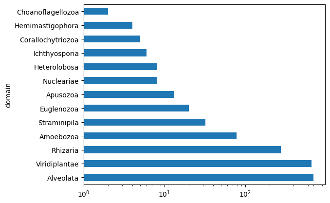

```python
# revisar composicion a nivel de reino
prottab['domain'].value_counts().plot.barh(log=True)
```

```python
# obtener grafico circular de reinos y filos
dom_phy_class_counts = pd.DataFrame(prottab.groupby(['domain',
                                                     'phylum'],
                                                    as_index=False)['class'].value_counts())
dom_phy_class_counts.info()
```

```
<class 'pandas.core.frame.DataFrame'>
RangeIndex: 36 entries, 0 to 35
Data columns (total 4 columns):
 #   Column  Non-Null Count  Dtype
---  ------  --------------  -----
 0   domain  36 non-null     object
 1   phylum  36 non-null     object
 2   class   36 non-null     object
 3   count   36 non-null     int64
dtypes: int64(1), object(3)
memory usage: 1.2+ KB
```

```python
fig = px.sunburst(dom_phy_class_counts,
                  path=['domain', 'phylum','class']
                 )
fig.show(renderer='colab')
```

[interactive chart not shown]

```python
fig = px.sunburst(dom_phy_class_counts,
                  path=['domain', 'phylum','class'],
                 values='count')
fig.show(renderer='colab')
```

[interactive chart not shown]

# Análisis ecológicos

```python
# extraemos los conteos y transponemos la tabla
potu = prottab[prottab.columns[11:]].copy()
potu.index = prottab['SPPN']
potu = potu.T
potu.info()
```

```
<class 'pandas.core.frame.DataFrame'>
Index: 34 entries, B39 to X63
Columns: 1812 entries, Trebouxiophyceae_0001 to Cercomonadidae_0110
dtypes: int64(1812)
memory usage: 481.6+ KB
```

## Diversidad alfa

```python
# revisar las metricas disponibles
skbio.diversity.get_alpha_diversity_metrics()
```

```
['ace',
 'berger_parker_d',
 'brillouin_d',
 'chao1',
 'chao1_ci',
 'dominance',
 'doubles',
 'enspie',
 'esty_ci',
 'faith_pd',
 'fisher_alpha',
 'gini_index',
 'goods_coverage',
 'heip_e',
 'hill',
 'inv_simpson',
 'kempton_taylor_q',
 'lladser_ci',
 'lladser_pe',
 'margalef',
 'mcintosh_d',
 'mcintosh_e',
 'menhinick',
 'michaelis_menten_fit',
 'observed_features',
 'observed_otus',
 'osd',
 'phydiv',
 'pielou_e',
 'register_aliases',
 'renyi',
 'robbins',
 'shannon',
 'simpson',
 'simpson_d',
 'simpson_e',
 'singles',
 'sobs',
 'strong',
 'tsallis']
```

```python
# obtener riqueza observada
skbio.diversity.alpha_diversity('sobs', potu)
```

```
B39     42
B40     41
B44     83
B46     70
B47     38
B48     62
B49     51
B51     59
B52     55
B53     63
B54     74
B60     52
B61    116
B63     54
B69    119
B71     41
B79    110
B80    104
B81    152
B82    100
B83     70
X39    162
X44    103
X46    252
X47     53
X48    250
X49    159
X51    196
X52    139
X53    189
X54    265
X60    184
X61    183
X63      3
dtype: int64
```

```python
# obtener indice de Shannon
skbio.diversity.alpha_diversity('shannon', potu)
```

```
B39    3.339537
B40    2.927101
B44    2.913396
B46    3.808989
B47    3.154685
B48    3.672897
B49    3.458053
B51    3.095917
B52    3.718243
B53    3.691896
B54    3.263947
B60    3.622360
B61    4.343123
B63    3.622852
B69    4.067334
B71    2.814538
B79    3.792239
B80    4.121354
B81    4.146265
B82    4.024747
B83    3.660619
X39    4.294925
X44    4.027894
X46    4.599587
X47    3.460074
X48    4.789588
X49    4.048600
X51    4.709968
X52    2.013307
X53    4.271835
X54    4.496094
X60    4.756406
X61    4.191072
X63    0.735622
dtype: float64
```

```python
# obtener diversidad de Simpson
skbio.diversity.alpha_diversity('simpson', potu)
```

```
B39    0.948785
B40    0.902473
B44    0.835255
B46    0.969595
B47    0.928483
B48    0.963419
B49    0.950697
B51    0.884745
B52    0.970341
B53    0.964620
B54    0.911651
B60    0.965486
B61    0.981337
B63    0.964208
B69    0.970967
B71    0.877432
B79    0.948370
B80    0.973316
B81    0.968104
B82    0.963657
B83    0.960207
X39    0.971888
X44    0.975003
X46    0.969533
X47    0.951811
X48    0.984545
X49    0.965055
X51    0.984284
X52    0.541275
X53    0.964699
X54    0.960925
X60    0.985721
X61    0.960989
X63    0.406250
dtype: float64
```

```python
# nueva tabla con diversidad por muestra
psdiv = pd.concat([skbio.diversity.alpha_diversity('sobs', potu),
          skbio.diversity.alpha_diversity('shannon', potu),
          skbio.diversity.alpha_diversity('simpson', potu)], axis=1)
psdiv.columns = ['sobs', 'shannon', 'simpson']
psdiv.info()
```

```
<class 'pandas.core.frame.DataFrame'>
Index: 34 entries, B39 to X63
Data columns (total 3 columns):
 #   Column   Non-Null Count  Dtype
---  ------   --------------  -----
 0   sobs     34 non-null     int64
 1   shannon  34 non-null     float64
 2   simpson  34 non-null     float64
dtypes: float64(2), int64(1)
memory usage: 2.1+ KB
```

```python
# creamos una nueva tabla de metadatos asignando nombres a las filas
smd = samplemd.copy()
smd.index = smd['Sample']
```

```python
# unir la tabla de diversidad con la nueva tabla de metadatos
psmd = pd.concat([smd, psdiv], axis=1)
psmd.info()
```

```
<class 'pandas.core.frame.DataFrame'>
Index: 34 entries, B39 to X63
Data columns (total 25 columns):
 #   Column                     Non-Null Count  Dtype
---  ------                     --------------  -----
 0   Sample                     34 non-null     object
 1   Soil System                34 non-null     object
 2   Vegetation_general         34 non-null     object
 3   Vegetation_description     34 non-null     object
 4   Altitude                   34 non-null     int64
 5   Climate                    34 non-null     object
 6   Soil_type                  34 non-null     object
 7   Municipality               34 non-null     object
 8   Collection_date            34 non-null     object
 9   Latitude                   34 non-null     float64
```

[output cut: 17 more lines]

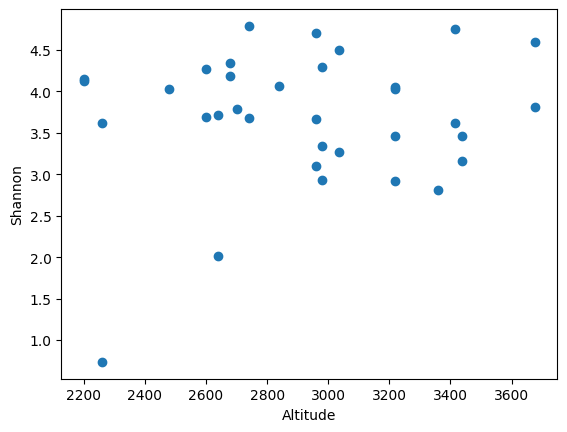

```python
# visualizar diversidad  vs metadato
plt.scatter(x=psmd['Altitude'], y=psmd['shannon'])
plt.xlabel('Altitude')
plt.ylabel('Shannon')
```

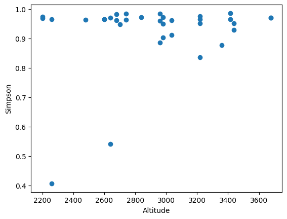

```python
# visualizar diversidad  vs metadato
plt.scatter(x=psmd['Altitude'], y=psmd['simpson'])
plt.xlabel('Altitude')
plt.ylabel('Simpson')
```

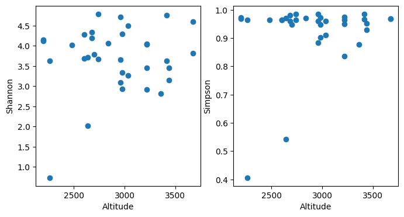

```python
# crear grafica compuesta
fig, ax = plt.subplots(1,2, figsize=(8,4))

ax[0].scatter(x=psmd['Altitude'], y=psmd['shannon'])
ax[0].set_xlabel('Altitude')
ax[0].set_ylabel('Shannon')

ax[1].scatter(x=psmd['Altitude'], y=psmd['simpson'])
ax[1].set_xlabel('Altitude')
ax[1].set_ylabel('Simpson')
```

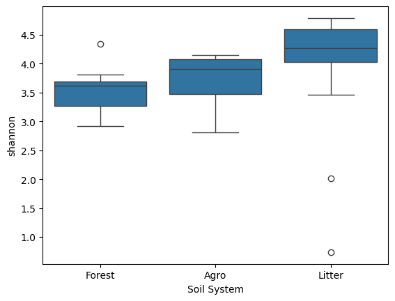

```python
# boxplot de diversidad por sistema
sns.boxplot(data=psmd, x='Soil System', y='shannon')
```

### Estadistica

```python
# Mann-Whitney U (t test no parametrico) test un solo par
result = scipy.stats.mannwhitneyu(psmd.loc[psmd['Soil System']=='Litter','shannon'],
                                  psmd.loc[psmd['Soil System']=='Forest','shannon'])

print("Statistic:", result.statistic)
print("P-value:", result.pvalue)
```

```
Statistic: 131.0
P-value: 0.018325521931295465
```

```python
# kruskal wallis (anova no parametrico)
scipy.stats.kruskal(psmd.loc[psmd['Soil System']=='Litter','shannon'],
                                  psmd.loc[psmd['Soil System']=='Forest','shannon'],
                                  psmd.loc[psmd['Soil System']=='Agro','shannon'])
```

```
KruskalResult(statistic=np.float64(6.966127989657394), pvalue=np.float64(0.03071316174805648))
```

```python
# mann whitney pareado
wilcox_pvals = pd.DataFrame(np.nan,
                            index=list(set(psmd['Soil System'])),
                            columns=list(set(psmd['Soil System']))) # pvalue
wilcox_ES = pd.DataFrame(np.nan,
                         index=list(set(psmd['Soil System'])),
                         columns=list(set(psmd['Soil System'])))    # statistic

passed_pairs = []
for i in wilcox_pvals.columns:
    for j in wilcox_pvals.index.values:
        if i != j:
            if (i,j) not in passed_pairs:
                try:
                    wilcox_pvals.loc[j,
                        i] = scipy.stats.mannwhitneyu(list(psmd.fillna(0).loc[psmd['Soil System']==i, 'shannon']),
                                                             list(psmd.fillna(0).loc[psmd['Soil System']==j, 'shannon']))[1]
                    wilcox_ES.loc[j,i] = scipy.stats.mannwhitneyu(list(psmd.fillna(0).loc[psmd['Soil System']==i, 'shannon']),
                                                             list(psmd.fillna(0).loc[psmd['Soil System']==j, 'shannon']))[0]

                except:
                    wilcox_pvals.loc[j,i] = np.nan
                    wilcox_ES.loc[j,i] = np.nan

        passed_pairs.append((j,i))
```

```python
# p-values crudos
wilcox_pvals
```

|  | Forest | Litter | Agro |
| --- | --- | --- | --- |
| Forest | NaN | NaN | NaN |
| Litter | 0.018326 | NaN | NaN |
| Agro | 0.268455 | 0.089046 | NaN |

```python
# ajustar p-values por comparaciones multiples
raw_pvals = []
passed_pairs = []
for i in wilcox_pvals.columns:
    for j in wilcox_pvals.index.values:
        if i != j:
            if (i,j) not in passed_pairs:
                raw_pvals.append(wilcox_pvals[i][j])
        passed_pairs.append((j,i))

adjusted_pvals = list(scipy.stats.false_discovery_control(raw_pvals))

wilcox_adjusted_pvals = pd.DataFrame(np.nan, index=list(set(psmd['Soil System'])), columns=list(set(psmd['Soil System'])))

passed_pairs = []
for i in wilcox_pvals.columns:
    for j in wilcox_pvals.index.values:
        if i != j:
            if (i,j) not in passed_pairs:
                wilcox_adjusted_pvals.loc[j,i] = round(adjusted_pvals.pop(0), 4)
        passed_pairs.append((j,i))
```

```python
# p-values ajustados
wilcox_adjusted_pvals
```

|  | Forest | Litter | Agro |
| --- | --- | --- | --- |
| Forest | NaN | NaN | NaN |
| Litter | 0.0550 | NaN | NaN |
| Agro | 0.2685 | 0.1336 | NaN |

## Diversidad beta

```python
# revisar metricas de diversidad beta
skbio.diversity.get_beta_diversity_metrics()
```

```
['braycurtis',
 'canberra',
 'chebyshev',
 'cityblock',
 'correlation',
 'cosine',
 'dice',
 'euclidean',
 'hamming',
 'jaccard',
 'jensenshannon',
 'mahalanobis',
 'manhattan',
 'matching',
 'minkowski',
 'rogerstanimoto',
 'russellrao',
 'seuclidean',
 'sokalsneath',
 'sqeuclidean',
 'unweighted_unifrac',
 'weighted_unifrac',
 'yule']
```

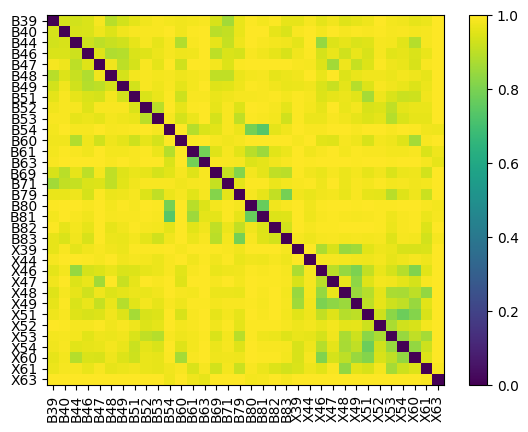

```python
# obtener distancias Jaccard (presencia/ausencia)
pbjacc = skbio.diversity.beta_diversity('jaccard', potu)
pbjacc.plot();
```

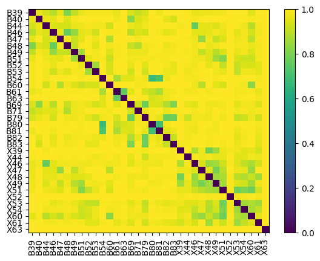

```python
# obtener distancia Bray-Curtis (abundancia)
pbbray = skbio.diversity.beta_diversity('braycurtis', potu)
pbbray.plot();
```

```python
# ordenamiento de coordenadas principales para Jaccard
pbjaccpc = skbio.stats.ordination.pcoa(pbjacc, dimensions=10)
# mostrar varianza explciada por eje
pbjaccpc.proportion_explained
```

```
PC1     0.077813
PC2     0.059123
PC3     0.056303
PC4     0.046323
PC5     0.041766
PC6     0.039578
PC7     0.035963
PC8     0.035450
PC9     0.033331
PC10    0.032750
dtype: float64
```

```python
# lo mismo para Bray-Curtis
pbbraypc = skbio.stats.ordination.pcoa(pbbray, dimensions=10)
pbbraypc.proportion_explained
```

```
PC1     0.080407
PC2     0.065971
PC3     0.059459
PC4     0.049776
PC5     0.045146
PC6     0.042273
PC7     0.041015
PC8     0.037772
PC9     0.036044
PC10    0.034356
dtype: float64
```

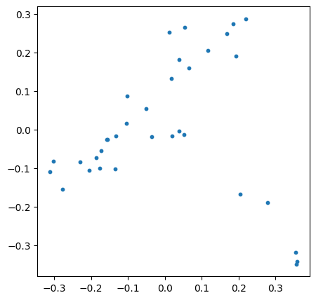

```python
# Visualizar ordenamiento en un biplano
fig, ax = plt.subplots(1,1, figsize=(5,5))

ax.scatter(pbbraypc.samples['PC1'], pbbraypc.samples['PC2'], s=10);
```

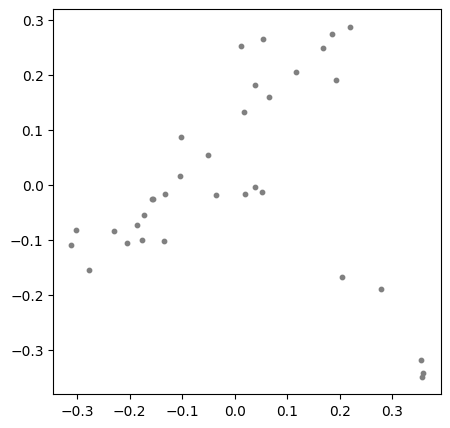

```python
# colorear igual
fig, ax = plt.subplots(1,1, figsize=(5,5))

ax.scatter(pbbraypc.samples['PC1'], pbbraypc.samples['PC2'], s=10, c='grey');
```

```python
psmd.columns
```

```
Index(['Sample', 'Soil System', 'Vegetation_general', 'Vegetation_description',
       'Altitude', 'Climate', 'Soil_type', 'Municipality', 'Collection_date',
       'Latitude', 'Longitude', 'pH', 'Moisture', 'Mean_annual_temperature',
       'Mean_annual_precipitation', 'Mean_evapotranspiration',
       'TC_total_carbon', 'TN_total_nitrogen', 'Tpt_total_phosphorus',
       'C/N_ratio', 'C/P_ratio', 'N/P_ratio', 'sobs', 'shannon', 'simpson'],
      dtype='object')
```

```python
# crear diccionario para colorear por municipio
s2muni_d = {ci:crow['Municipality'] for ci, crow in psmd.iterrows()}
```

```python
s2muni_d
```

```
{'B39': 'Tlalpan',
 'B40': 'Tlalpan',
 'B44': 'Tlalpan',
 'B46': 'Tlalpan',
 'B47': 'Tlalpan',
 'B48': 'Tlalpan',
 'B49': 'Tlalpan',
 'B51': 'Tlalpan',
 'B52': 'Xochimilco',
 'B53': 'Xochimilco',
 'B54': 'Tlalpan',
 'B60': 'Tlalpan',
 'B61': 'Xochimilco',
 'B63': 'Xochimilco',
 'B69': 'Tlalpan',
 'B71': 'Tlalpan',
 'B79': 'Xochimilco',
 'B80': 'Xochimilco',
 'B81': 'Xochimilco',
 'B82': 'Xochimilco',
 'B83': 'Xochimilco',
 'X39': 'Tlalpan',
 'X44': 'Tlalpan',
 'X46': 'Tlalpan',
 'X47': 'Tlalpan',
 'X48': 'Tlalpan',
 'X49': 'Tlalpan',
 'X51': 'Tlalpan',
 'X52': 'Xochimilco',
 'X53': 'Xochimilco',
 'X54': 'Tlalpan',
 'X60': 'Tlalpan',
 'X61': 'Xochimilco',
 'X63': 'Xochimilco'}
```

```python
# ejemplo de como funciona un diccionario
s2muni_d['B39']
```

```
'Tlalpan'
```

```python
# diccionario para asignar color
color_dict_m = {'Tlalpan':'goldenrod','Xochimilco':'lightskyblue'}
```

```python
color_dict_m['Tlalpan']
```

```
'goldenrod'
```

```python
color_dict_m[s2muni_d['B39']]
```

```
'goldenrod'
```

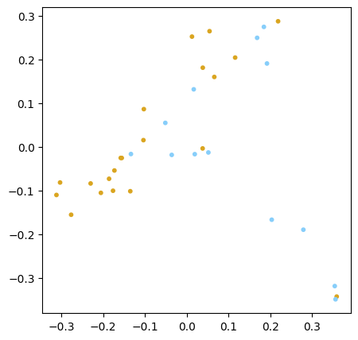

```python
# colorear
fig, ax = plt.subplots(1,1, figsize=(5,5))

ax.scatter(pbbraypc.samples['PC1'], pbbraypc.samples['PC2'], s=10,
           c=[color_dict_m[s2muni_d[ci]] for ci in pbbraypc.samples.index]);
```

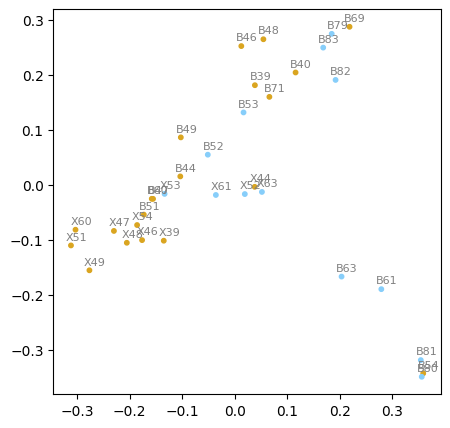

```python
# colorear
fig, ax = plt.subplots(1,1, figsize=(5,5))

ax.scatter(pbbraypc.samples['PC1'], pbbraypc.samples['PC2'], s=10,
           c=[color_dict_m[s2muni_d[ci]] for ci in pbbraypc.samples.index]);

# anotar puntos
for ci, crow in pbbraypc.samples.iterrows():
    ax.annotate(ci, (crow['PC1']-0.01, crow['PC2']+0.01), size=8, color='grey')
```

```python
# colorear por sistema
color_dict_s = {'Agro':'chocolate','Forest':'forestgreen','Litter':'gold'}
```

```python
# crear diccionario para asignar sistema a las muestras
s2sys_d =  {ci:crow['Soil System'] for ci, crow in psmd.iterrows()}
```

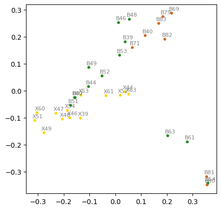

```python
# colorear por sistema
fig, ax = plt.subplots(1,1, figsize=(5,5))

ax.scatter(pbbraypc.samples['PC1'], pbbraypc.samples['PC2'], s=10,
           c=[color_dict_s[s2sys_d[ci]] for ci in pbbraypc.samples.index]);

# anotar puntos
for ci, crow in pbbraypc.samples.iterrows():
    ax.annotate(ci, (crow['PC1']-0.01, crow['PC2']+0.01), size=8, color='grey')
```

```python
# diccionario para asignar pH
s2ph_d =  {ci:crow['pH'] for ci, crow in psmd.iterrows()}
```

```python
s2ph_d['B39']
```

```
5.16
```

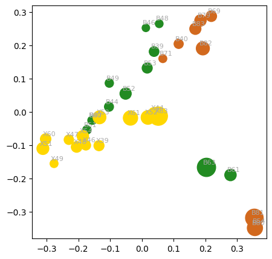

```python
# colorear por sistema y ajustar tamaño
fig, ax = plt.subplots(1,1, figsize=(5,5))

ax.scatter(pbbraypc.samples['PC1'], pbbraypc.samples['PC2'], s=[s2ph_d[ci]**3 for ci in pbbraypc.samples.index],
           c=[color_dict_s[s2sys_d[ci]] for ci in pbbraypc.samples.index]);

# anotar puntos
for ci, crow in pbbraypc.samples.iterrows():
    ax.annotate(ci, (crow['PC1']-0.01, crow['PC2']+0.01), size=8, color='darkgrey')
```

### permanova y anosim

```python
# permanova
skbio.stats.distance.permanova(pbbray, psmd, 'Soil System')
```

```
method name               PERMANOVA
test statistic name        pseudo-F
sample size                      34
number of groups                  3
test statistic             1.797021
p-value                       0.001
number of permutations          999
Name: PERMANOVA results, dtype: object
```

```python
# permanova
skbio.stats.distance.permanova(pbbray, psmd, 'Municipality')
```

```
method name               PERMANOVA
test statistic name        pseudo-F
sample size                      34
number of groups                  2
test statistic             1.714576
p-value                       0.001
number of permutations          999
Name: PERMANOVA results, dtype: object
```

```python
# anosim
skbio.stats.distance.anosim(pbbray, psmd, 'Soil System')
```

```
method name                ANOSIM
test statistic name             R
sample size                    34
number of groups                3
test statistic            0.30997
p-value                     0.001
number of permutations        999
Name: ANOSIM results, dtype: object
```

```python
# anosim
skbio.stats.distance.anosim(pbbray, psmd, 'Municipality')
```

```
method name                 ANOSIM
test statistic name              R
sample size                     34
number of groups                 2
test statistic            0.346396
p-value                      0.001
number of permutations         999
Name: ANOSIM results, dtype: object
```

#### Correlacionar con variables ambientales

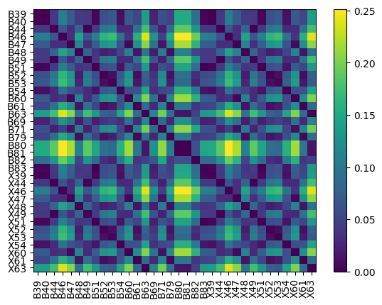

```python
# crear matriz de distancia de variables ambientales
envbbray = skbio.diversity.beta_diversity('braycurtis', smd[['Altitude','pH','Moisture']])
envbbray.plot();
```

```python
# prueba de correlacion de matrices de distancia
skbio.stats.distance.mantel(pbbray, envbbray)
```

```
(np.float64(0.21902992438425448), np.float64(0.001), 34)
```

# Predecir asociaciones

```python
# calcular correlaciones

# renombrar variables
otu_table = potu
otu_names = potu.columns

# crear matriz de presencia/ausencia
presence_matrix = (otu_table > 0).astype(int)
co_occurrence = presence_matrix.T.dot(presence_matrix)

# calcular correlacion
corr_matrix, pval_matrix = scipy.stats.spearmanr(otu_table, axis=0)

# obtener indices para evitar auto-correlaciones
row_idx, col_idx = np.triu_indices_from(co_occurrence, k=1)

# marcar pares que comparten por lo menos 3 muestras
valid_mask = co_occurrence.values[row_idx, col_idx] >= 3

# obtener filas y columnas filtradas
valid_rows = row_idx[valid_mask]
valid_cols = col_idx[valid_mask]

# crear una tabla con los valores validos
results_df = pd.DataFrame({
    'OTU1': otu_names[valid_rows],
    'OTU2': otu_names[valid_cols],
    'Correlation': corr_matrix[valid_rows, valid_cols],
    'PValue': pval_matrix[valid_rows, valid_cols]
})

# corregir p-values
results_df['AdjustedPValue'] = multipletests(results_df['PValue'], method='fdr_bh')[1]
results_df.sort_values(by=['Correlation', 'AdjustedPValue'], ascending=[False, True], inplace=True)
```

```python
# mostrar dimensiones de la tabla
results_df.shape
```

```
(7388, 5)
```

```python
# filtrar por coeficiente y p-value ajustado
results_dff = results_df.loc[(results_df['AdjustedPValue']< 0.001)&(np.absolute(results_df['Correlation'])>= 0.99)].copy()
results_dff.shape
```

```
(126, 5)
```

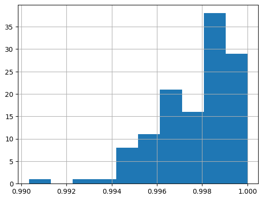

```python
# histograma de los coeficientes de correlacion
results_dff['Correlation'].hist()
```

```python
# crear diccionario para asignar taxonomia
tax_d = {crow['SPPN']:crow['domain'] for ci,crow in prottab.iterrows()}
```

```python
# agregar taxonomia
results_dff['AdjPValue'] = results_dff['AdjustedPValue']
results_dff['OTU1_kingdom'] = [tax_d[results_dff['OTU1'][i]] for i in results_dff.index.values]
results_dff['OTU2_kingdom'] = [tax_d[results_dff['OTU2'][i]] for i in results_dff.index.values]
results_dff['cross_kingdom'] = [results_dff['OTU1'][i] != results_dff['OTU2'][i] for i in results_dff.index.values]
```

```python
# revisar numero de pares con diferente reino
results_dff['cross_kingdom'].value_counts()
```

```
cross_kingdom
True    126
Name: count, dtype: int64
```

```python
results_dff['OTU1_kingdom'].unique()
```

```
array(['Alveolata', 'Viridiplantae', 'Straminipila', 'Rhizaria',
       'Euglenozoa', 'Amoebozoa'], dtype=object)
```

```python
results_dff['OTU2_kingdom'].unique()
```

```
array(['Viridiplantae', 'Alveolata', 'Rhizaria', 'Euglenozoa',
       'Straminipila', 'Heterolobosa', 'Amoebozoa'], dtype=object)
```

```python
# obtener lista de reinos con correlaciones
list(set(list(results_dff['OTU1_kingdom'].unique()) + list(results_dff['OTU2_kingdom'].unique())))
```

```
['Amoebozoa',
 'Rhizaria',
 'Alveolata',
 'Heterolobosa',
 'Viridiplantae',
 'Straminipila',
 'Euglenozoa']
```

## Analisis de red

```python
# asignar color por reino
king2col_d = {'Heterolobosa':'green',
 'Alveolata':'goldenrod',
 'Amoebozoa':'red',
 'Rhizaria':'pink',
 'Straminipila':'cyan',
 'Viridiplantae':'green',
 'Euglenozoa':'grey'}
```

```python
# Crear la red
G = nx.Graph()

# agregar aristas y pesos
for index, row in results_dff.iterrows():
    otu1 = row['OTU1']
    otu2 = row['OTU2']
    G.add_edge(otu1, otu2, weight=row['Correlation'], pvalue=row['AdjustedPValue'])

# definir la separacion de los nodos basada en k
pos = nx.spring_layout(G, k=0.5)
```

```python
# revisar numero de nodos
len(G.nodes)
```

```
99
```

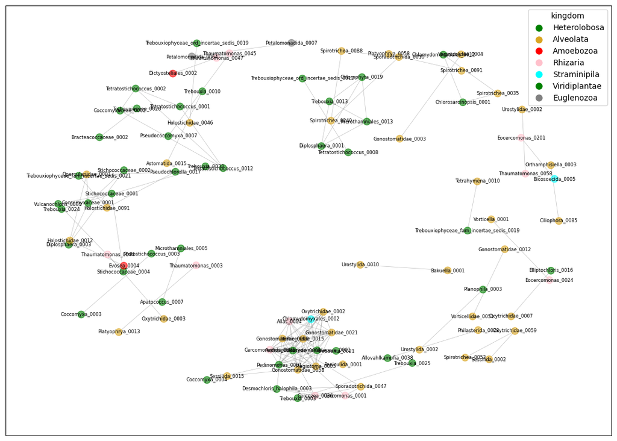

```python
# graficar
plt.figure(figsize=(14, 10))
edges = G.edges(data=True)

# aristas
nx.draw_networkx_edges(G, pos, edgelist=edges, width=[0.5 * abs(d['weight']) for (u, v, d) in edges],
                         alpha=0.5, edge_color='grey')

# nodos
node_labels = {otu: f"{otu}" for otu in G.nodes()}
node_colors = [king2col_d[tax_d[otu]] for otu in G.nodes()]
nx.draw_networkx_nodes(G, pos, node_size=80, node_color=node_colors, alpha=0.6)

# etiquetas
nx.draw_networkx_labels(G, pos, labels=node_labels, font_size=6, font_color='black')

# agregar leyenda
legend_handles = [plt.Line2D([0], [0], marker='o', color='w', markerfacecolor=ccol, markersize=10, label=cclass)
                  for cclass, ccol in king2col_d.items()]

plt.legend(handles=legend_handles, title='kingdom')

# guarda figura
plt.savefig('red.svg')
```

```python
# guardar tabla de resultados
results_df.to_csv('xt_protista_corrs.tsv', sep='\t', index=False)
```

```python
# obtener estadisticos
netmet_d = {}
print('degree')
netmet_d['res_degree'] = nx.degree(G)

print('degree_centrality')
netmet_d['res_degree_centrality'] = nx.degree_centrality(G)

print('betweenness_centrality')
netmet_d['res_betweenness_centrality'] = nx.betweenness_centrality(G)

print('closeness_centrality')
netmet_d['res_closeness_centrality'] = nx.closeness_centrality(G)
```

```
degree
degree_centrality
betweenness_centrality
closeness_centrality
```

```python
# crear tabla con estadisticos de redes
netres = pd.DataFrame(index=netmet_d['res_betweenness_centrality'].keys())
netres['degree'] = [netmet_d['res_degree'][ci] for ci in netres.index]
netres['degree_centrality'] = [netmet_d['res_degree_centrality'][ci] for ci in netres.index]
netres['betweenness_centrality'] = [netmet_d['res_betweenness_centrality'][ci] for ci in netres.index]
netres['closeness_centrality'] = [netmet_d['res_closeness_centrality'][ci] for ci in netres.index]
```

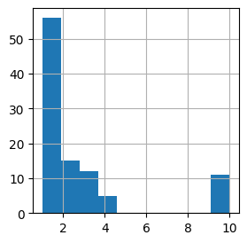

```python
# histograma de degree
netres['degree'].hist(figsize=(3,3))
```

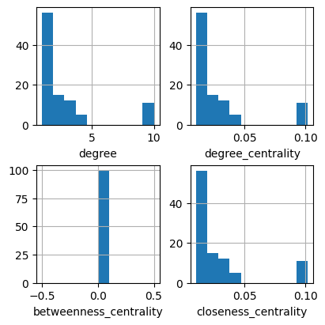

```python
# grafico compuesto de histogramas
fig, ax = plt.subplots(2,2, figsize=(4,4), constrained_layout=True)

netres['degree'].hist(ax=ax[0,0])
ax[0,0].set_xlabel('degree')

netres['degree_centrality'].hist(ax=ax[0,1])
ax[0,1].set_xlabel('degree_centrality')

netres['betweenness_centrality'].hist(ax=ax[1,0])
ax[1,0].set_xlabel('betweenness_centrality')

netres['closeness_centrality'].hist(ax=ax[1,1])
ax[1,1].set_xlabel('closeness_centrality')
```

```python
# agregar taxonomia
netres['kingdom'] = [tax_d[ci] for ci in netres.index]
```

```python
# visualizar 20 ASVs con mayor degree centrality
netres.sort_values('degree_centrality', ascending=False).head(20)
```

|  | degree | degree_centrality | betweenness_centrality | closeness_centrality | kingdom |
| --- | --- | --- | --- | --- | --- |
| Oxytrichidae_0002 | 10 | 0.102041 | 0.0 | 0.102041 | Alveolata |
| Chlamydomonadaceae_0001 | 10 | 0.102041 | 0.0 | 0.102041 | Viridiplantae |
| Gonostomatidae_0058 | 10 | 0.102041 | 0.0 | 0.102041 | Alveolata |
| Vorticellidae_0015 | 10 | 0.102041 | 0.0 | 0.102041 | Alveolata |
| Plagiotoma_0003 | 10 | 0.102041 | 0.0 | 0.102041 | Alveolata |
| Chlamydomyxales_0002 | 10 | 0.102041 | 0.0 | 0.102041 | Straminipila |
| Allas_0004 | 10 | 0.102041 | 0.0 | 0.102041 | Rhizaria |
| Cercomonadida_0071 | 10 | 0.102041 | 0.0 | 0.102041 | Rhizaria |
| Protosiphonaceae_0003 | 10 | 0.102041 | 0.0 | 0.102041 | Viridiplantae |
| Pedinomonas_0001 | 10 | 0.102041 | 0.0 | 0.102041 | Viridiplantae |
| Gonostomatidae_0021 | 10 | 0.102041 | 0.0 | 0.102041 | Alveolata |
| Desmochloris_halophila_0003 | 4 | 0.040816 | 0.0 | 0.040816 | Viridiplantae |
| Gonostomatidae_0019 | 4 | 0.040816 | 0.0 | 0.040816 | Alveolata |
| Sporadotrichida_0047 | 4 | 0.040816 | 0.0 | 0.040816 | Alveolata |
| Cercomonas_0001 | 4 | 0.040816 | 0.0 | 0.040816 | Rhizaria |
| Cercozoa_0036 | 4 | 0.040816 | 0.0 | 0.040816 | Rhizaria |
| Coccomyxaceae_0002 | 3 | 0.030612 | 0.0 | 0.030612 | Viridiplantae |
| Tetratostichococcus_0001 | 3 | 0.030612 | 0.0 | 0.030612 | Viridiplantae |
| Diplosphaera_0001 | 3 | 0.030612 | 0.0 | 0.030612 | Viridiplantae |
| Coccomyxaceae_0001 | 3 | 0.030612 | 0.0 | 0.030612 | Viridiplantae |

# Conclusion

Realizamos algunos ejemplos de como visualizar datos y hacer algunos análisis ecológicos con python, pero se recomienda explorar las librerías iNEXT, vegan y phyloseq para analizar datos de metabarcoding en R también.